# Wprowadzenie do modeli mieszanych

Przemyslaw Biecek

# Postać modelu

Przypomnijmy postać modelu dla modeli mieszanych, mówiliśmy o niej na ostatnich zajęciach.

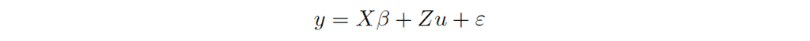

$\varepsilon$ i $u$ odpowiadają efektom losowym, to wielowymiarowe zmienne losowe o rozkładzie normalnym z macierzą wariancji $I$ i $D$.

Tak więc rozkład y to.

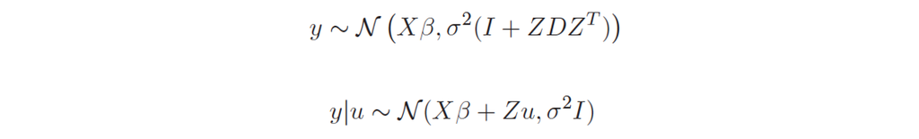

# Estymacja

W jaki sposób estymuje się parametry w takim modelu? Przedstawimy dwa podejścia, zacznijmy od metody największej wiarogodności.

Zaczynamy od funkcji największej wiarogodności.

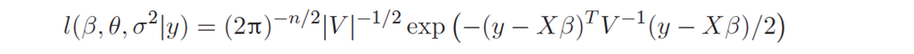

Łatwiej będzie pracować z funkcją -2 logarytmy z funkcji wiarogodności. Po usunięciu stałych mamy.

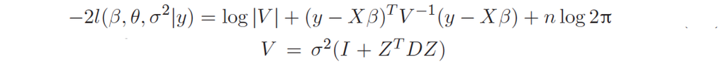

## Profiling

Ile mamy parametrów w tym modelu?

Ponieważ parametry będziemy estymować w sposób numeryczny. Postarajmy się więc zmniejszyć wymiar przestrzeni parametrów usuwając te, które można wyznaczyć w sposób analityczny - ten proces nazywa się profilowaniem.

Wiele stopni swobody możemy usunąć przez wyprofilowanie parametrów w $\beta$.

Zauważ, że dla znanego $V$ można ocenić parametry $\beta$ ze wzoru na ważone najmniejsze kwadraty.

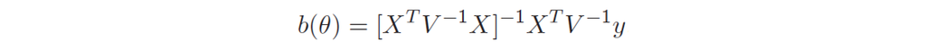

W podobny sposób można wydobyć $\sigma^2$ z macierzy $V$. Rozdzielmy te parametry w poniższym zapisie.

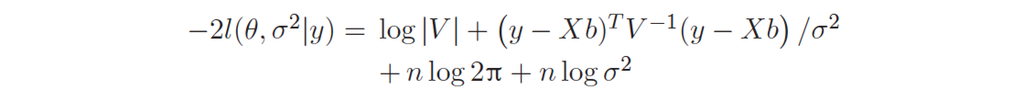

Tutaj potrzebna jest krótka dyskusja. Zmniejszyliśmy liczbę parametrów do estymacji, ale wciąż są to parametry zakłócające (confounding parameters).

Z tego powodu często rozważa się inną metodę estymacji opartą o funkcję resztowej/ograniczonej funkcji wiarygodności (restricted maximum likelihood, REML).

Pomysł stojący za metodą REML to usunięcie zakłócającego wpływu oceny parametrów $\beta$ przez niezależną estymację parametrów z $V$ na przestrzenia ortogonalnej do $X$ (przestrzeń bez parametrów $\beta$).

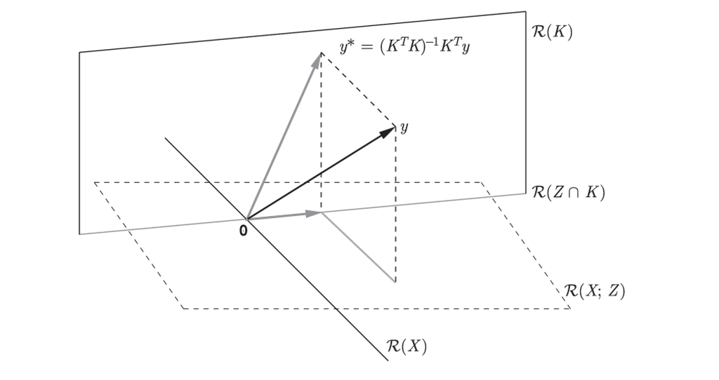

I postać modeli bez $\beta$

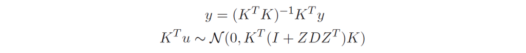

I dla takiego modelu możemy zapisać funkcję wiarogodności.

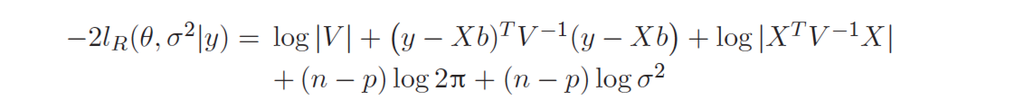

## More profiling

Tak jak powiedzieliśmy, możemy wyprofilować też $\sigma^2$ (poniżej $V^*$ to $V/\sigma^2$)

Skoro rozdzieliliśmy $V^2$ i $\sigma^2$, można teraz policzyć pochodną po $\sigma^2$ i otrzymać

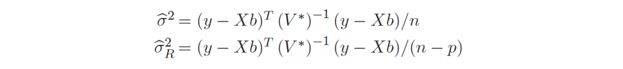

Po tym profilowaniu wystarczy wyestymować parametry $\theta$ w macierzy $V$. Funkcja wiarogodności dla $\theta$

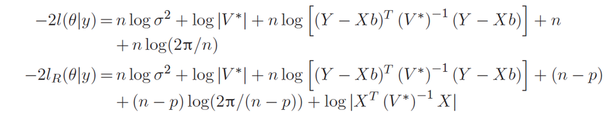

## Newton Raphson

A więc jak wyestymować parametry w $\theta$?

Można użyć ogólnego schematu optymalizacji Newtona-Raphsona,

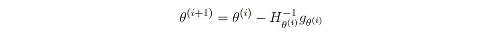

potrzebujemy tylko wektora pierwszych pochodnych i macierzy drugich pochodnych dla $\theta$.

W ogólności te pochodne wylicza się w dosyć żmudny sposób….

Dla ML

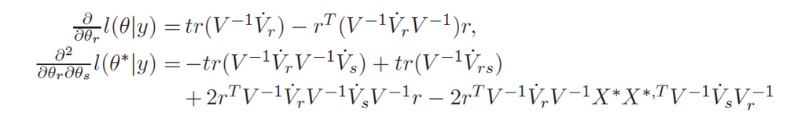

Dla REML

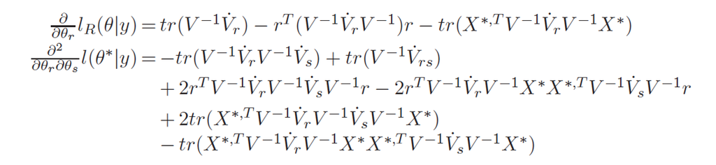

W ogolności nie jest to proste, ale dla wielu modelu otrzymuje się proste macierze $D$ a przez to i macierz $V$ ma prostą postać.

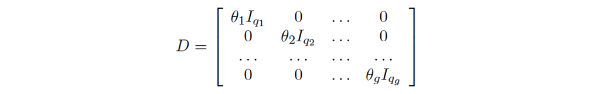

macierz $V$ redukuje się do

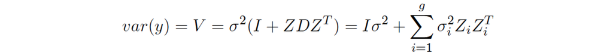

## Równania Hendersona

Jak dotąd traktowaliśmy $u$ jako losowe wartości, ale czasem warto by było znać ich oceny. Słowo ‘ocena’ nie jest właściwe, ponieważ rezerwowaliśmy je dla parametrów stałych w modelu, dlatego będziemy używać słowa `predykcje`.

A więc jak policzyć predykcje dla $u$?

Charles Hnderson zastosował by oprzeć je na funkcji wiarogodności dla wektora stałych i losowych parametrów $(\beta, u)$.

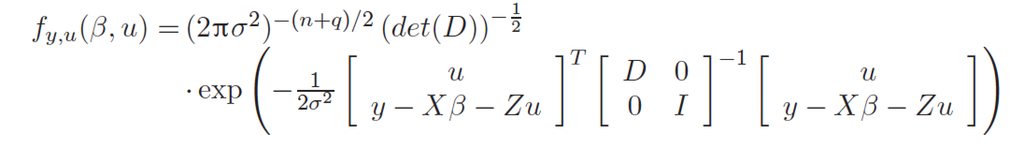

Minimalizacja z uwagi na $u$ i $\beta$ jest równoważna minimalizacji

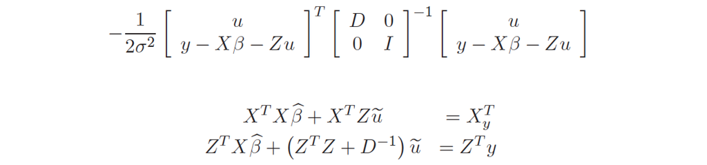

I ostatecznie dostajemy równania Hendersona

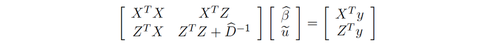

# Rozkłady dla ocen $\beta$ i $u$

Z powyższego wzoru dostajemy też rozkład dla macierzy wariancji $\beta$ i $u$

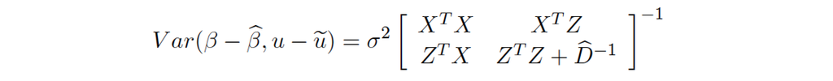

# Jak testować parametry w modelu?

Zazwyczaj stosuje się trzy podejścia

- Test Walda (for n >> p), i.e. $\hat\beta/se(\hat\beta)$ ma rozkład asymptotyczny $N(0,1)$,
- Test ilorazu wiarygodności, rozkład asymptotyczny statystyki testowej to rozkład $\chi^2$
- testy permutacyjne (bardziej wymagające obliczeniowo, ale o mniejszych założeniach dotyczących rozkładów).

# Jeden komponent losowy

## Dane `corn`

Zacznijmy od modelu dla ekspresji genów kukurydzianych.

### Pytanie

```r
library(PBImisc)
corn[1:3,1:7]
```

```
##               DH.C.1   DH.C.1   DH.C.1   DH.C.2   DH.C.2   DH.C.2   DH.C.3
## MZ00056801 12.203489 8.769006 6.846193 5.369957 7.355085 6.431522 5.998226
## MZ00056807  6.133096 9.637903 6.772756 4.433962 7.644376 9.234691 6.629690
## MZ00056825  7.244813 6.984742 7.930812 5.531837 7.258159 8.389686 8.040021
```

```r
# DH.C.1 DH.C.1 DH.C.1 DH.C.2 DH.C.2 DH.C.2 DH.C.3
# MZ00056801 12.203489 8.769006 6.846193 5.369957 7.355085 6.431522 5.998226
# MZ00056807 6.133096 9.637903 6.772756 4.433962 7.644376 9.234691 6.629690
# MZ00056825 7.244813 6.984742 7.930812 5.531837 7.258159 8.389686 8.040021
```

Zobaczmy jak wygląda model dla jednego genu

```r
# We will convert column names into three dependent variables
cnames = colnames(corn)
X = t(matrix(unlist(strsplit(cnames, ".", fixed=T)), 3, 36))
X = data.frame(X)
colnames(X) = c("species", "temperature", "plant")

summary(X)
```

```
##  species temperature plant
##  DH:18   C:18        1:12
##  DL:18   K:18        2:12
##                      3:12
```

Wybierzmy jeden gen

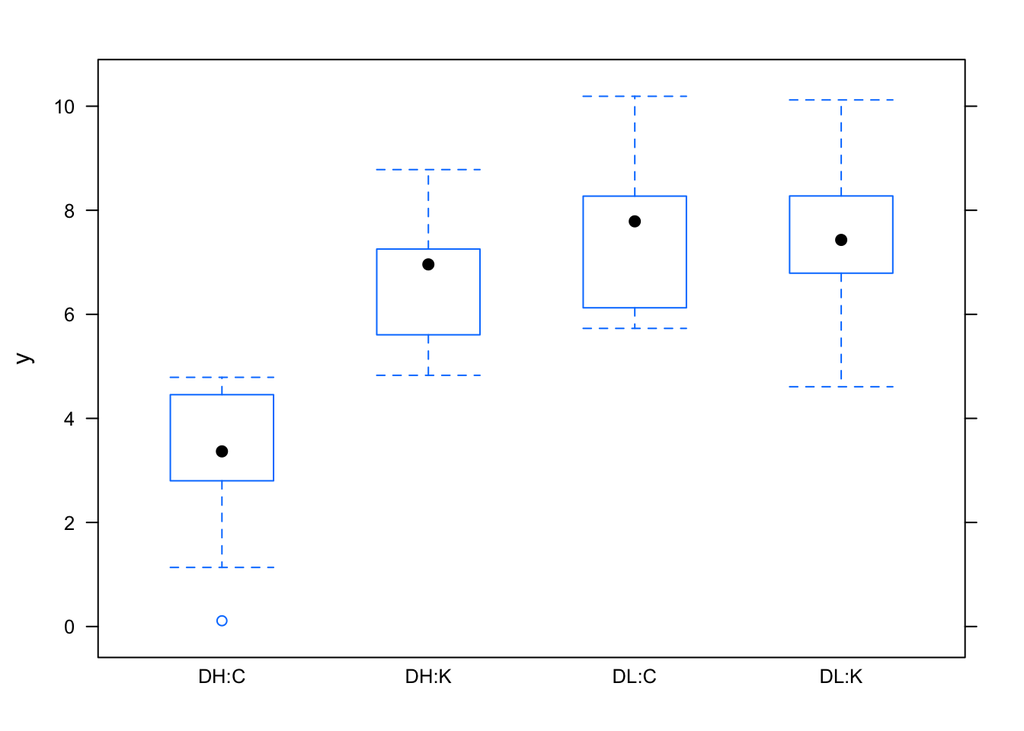

```r
y = corn[4613,]

library(lattice)
bwplot(y~species:temperature, data=X)
```

```r
# let's see what are the averages in each group
by(y, X$species:X$temperature, mean)
```

```
## X$species:X$temperature: DH:C
## [1] 3.181692
## --------------------------------------------------------
## X$species:X$temperature: DH:K
## [1] 6.55726
## --------------------------------------------------------
## X$species:X$temperature: DL:C
## [1] 7.534132
## --------------------------------------------------------
## X$species:X$temperature: DL:K
## [1] 7.512712
```

A więc jak wyglądają modele z dla tego genu?

### Trzy modele, trzy oceny

```r
summary(lm(y~species*temperature, data=X))
```

```
##
## Call:
## lm(formula = y ~ species * temperature, data = X)
##
## Residuals:
##     Min      1Q  Median      3Q     Max
## -3.0710 -0.9286  0.2186  0.9402  2.6565
##
## Coefficients:
##                        Estimate Std. Error t value Pr(>|t|)
## (Intercept)              3.1817     0.5043   6.309 4.45e-07 ***
## speciesDL                4.3524     0.7132   6.103 8.06e-07 ***
## temperatureK             3.3756     0.7132   4.733 4.31e-05 ***
## speciesDL:temperatureK  -3.3970     1.0086  -3.368  0.00198 **
## ---
## Signif. codes:  0 '***' 0.001 '**' 0.01 '*' 0.05 '.' 0.1 ' ' 1
##
## Residual standard error: 1.513 on 32 degrees of freedom
## Multiple R-squared:  0.6102, Adjusted R-squared:  0.5737
## F-statistic:  16.7 on 3 and 32 DF,  p-value: 1.042e-06
```

```r
summary(lm(y~species:temperature, data=X))
```

```
##
## Call:
## lm(formula = y ~ species:temperature, data = X)
##
## Residuals:
##     Min      1Q  Median      3Q     Max
## -3.0710 -0.9286  0.2186  0.9402  2.6565
##
## Coefficients: (1 not defined because of singularities)
##                        Estimate Std. Error t value Pr(>|t|)
## (Intercept)             7.51271    0.50428  14.898 6.02e-16 ***
## speciesDH:temperatureC -4.33102    0.71316  -6.073 8.79e-07 ***
## speciesDL:temperatureC  0.02142    0.71316   0.030    0.976
## speciesDH:temperatureK -0.95545    0.71316  -1.340    0.190
## speciesDL:temperatureK       NA         NA      NA       NA
## ---
## Signif. codes:  0 '***' 0.001 '**' 0.01 '*' 0.05 '.' 0.1 ' ' 1
##
## Residual standard error: 1.513 on 32 degrees of freedom
## Multiple R-squared:  0.6102, Adjusted R-squared:  0.5737
## F-statistic:  16.7 on 3 and 32 DF,  p-value: 1.042e-06
```

```r
library(lme4)
model1 = lmer(y~species*temperature + (1|plant:species:temperature), data=X)
summary(model1)$coefficients
```

```
##                         Estimate Std. Error   t value
## (Intercept)             3.181692  0.5597219  5.684416
## speciesDL               4.352439  0.7915664  5.498515
## temperatureK            3.375568  0.7915664  4.264416
## speciesDL:temperatureK -3.396988  1.1194439 -3.034532
```

```r
modelM = lmer(y~species*temperature + (1|plant:species:temperature), data=X, contrasts = list(species="contr.sum", temperature="contr.sum"))
printCoefmat(summary(modelM)$coef[1:4,])
```

```
##                       Estimate Std. Error t value
## (Intercept)            6.19645    0.27986 22.1412
## species1              -1.32697    0.27986 -4.7415
## temperature1          -0.83854    0.27986 -2.9963
## species1:temperature1 -0.84925    0.27986 -3.0345
```

```r
modelL = lm(y~species*temperature + plant:species:temperature, data=X, contrasts = list(species="contr.sum", temperature="contr.sum"))
printCoefmat(summary(modelL)$coef)
```

```
##                                Estimate Std. Error t value  Pr(>|t|)
## (Intercept)                    6.729426   0.419495 16.0417 2.494e-14 ***
## species1                      -0.990714   0.419495 -2.3617   0.02665 *
## temperature1                  -1.148995   0.419495 -2.7390   0.01143 *
## species1:temperature1         -0.777518   0.419495 -1.8535   0.07615 .
## speciesDH:temperatureC:plant2 -0.065715   1.186512 -0.0554   0.95629
## speciesDL:temperatureC:plant2  0.208572   1.186512  0.1758   0.86194
## speciesDH:temperatureK:plant2 -0.963824   1.186512 -0.8123   0.42459
## speciesDL:temperatureK:plant2  0.130022   1.186512  0.1096   0.91365
## speciesDH:temperatureC:plant3 -1.825806   1.186512 -1.5388   0.13693
## speciesDL:temperatureC:plant3  0.347837   1.186512  0.2932   0.77192
## speciesDH:temperatureK:plant3 -2.360073   1.186512 -1.9891   0.05821 .
## speciesDL:temperatureK:plant3 -1.866739   1.186512 -1.5733   0.12874
## ---
## Signif. codes:  0 '***' 0.001 '**' 0.01 '*' 0.05 '.' 0.1 ' ' 1
```

### Testujemy dla każdego genu

Powtórzmy te obliczenia dla każdego genu

```r
N = nrow(corn)
# p-values for fixed effects will be stored in mat matrix
mat_random = matrix(0, N, 3)
mat_fixed = matrix(0, N, 3)
# variance components will be stored in the matrix war
war = numeric(N)
for (i in 1:N) {
 y = corn[i,]
 model = lmer(y~species*temperature + (1|plant:species:temperature), data=X, contrasts = list(species="contr.sum", temperature="contr.sum"))
 mat_random[i,] = summary(model)$coef[2:4,3]
 war[i] = var(ranef(model)[[1]])

 modelL = lm(y~species*temperature + plant:species:temperature, data=X, contrasts = list(species="contr.sum", temperature="contr.sum"))
 mat_fixed[i,] = summary(modelL)$coef[2:4,3]
}
head(mat_random)
```

```
##            [,1]       [,2]       [,3]
## [1,] -0.8028583  1.2453462  0.7255928
## [2,]  1.1355626 -0.1210111  1.4871259
## [3,]  1.3345722 -0.4885138 -0.3376855
## [4,]  0.2330015  0.2897450 -1.1766340
## [5,] -0.8795928  0.8383740  0.4394400
## [6,] -1.1545574 -1.7344318 -0.8507543
```

```r
head(mat_fixed)
```

```
##            [,1]       [,2]       [,3]
## [1,] -0.3911990  2.8344097  0.8949158
## [2,]  0.2238197  1.2577034 -0.2322350
## [3,]  1.2421124  0.4516554 -0.5429439
## [4,]  1.4496939  0.1297355 -3.8377764
## [5,] -4.5118459 -1.8395065  1.3384310
## [6,] -0.4530163 -1.2349709 -0.1527357
```

Jak podsumować wyniki tego testowania?

Można wykorzystac diagramy Venna.

```r
alpha = 0.001
(c = -qnorm(alpha/2))
```

```
## [1] 3.290527
```

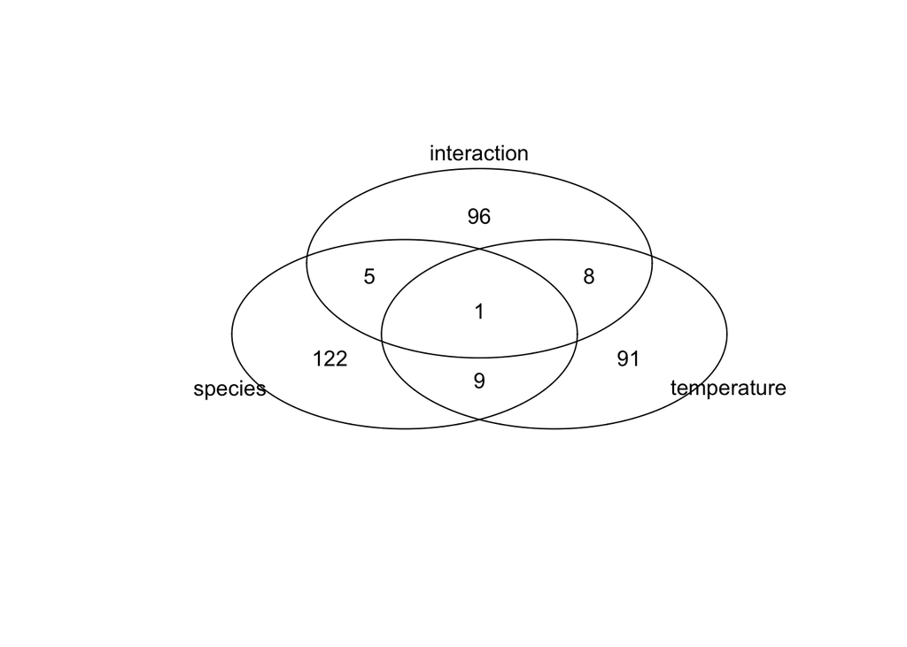

```r
tmp = as.data.frame(abs(mat_fixed) > c)
colnames(tmp) = c("species","temperature","interaction")
tmp2 = as.data.frame(abs(mat_random) > c)
colnames(tmp2) = c("species","temperature","interaction")
library(gplots)
venn(tmp)
```

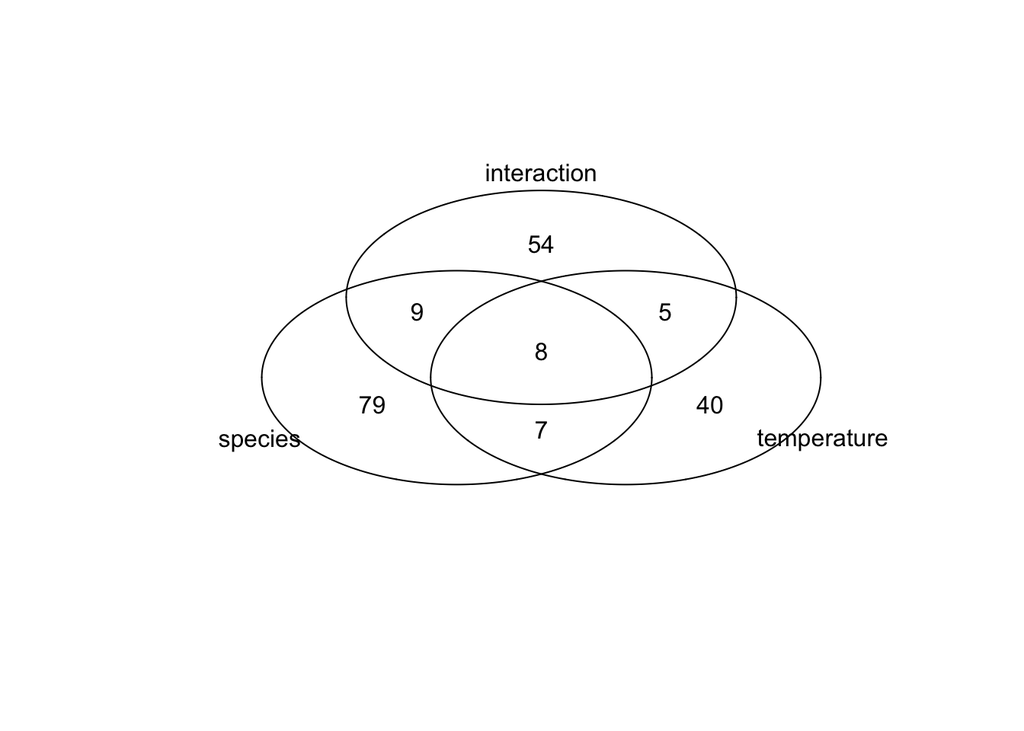

```r
venn(tmp2)
```

Modele z efektem stałym mają więcej istotnych genów. Ale czy to nie jest artefakt większej wariancji tych ocen?

Modele z efektem losowym mają mniej istotnych genów, ale przecięcie istotnych genów jest większe.

# Dwa komponenty

## The EUNOMIA study

Przykład dotyczyć będzie badania EUNOMIA: European Evaluation of Coercion in Psychiatry and Harmonisation of Best Clinical Practise

- BPRS - średnia dla Brief Psychiatric Rating Scale, mierzona w czasach: T1, T2 and T3
- CAT - Clients Scale for Assessment of Treatment, krótka ocena, mierzy ocenę leczeni aprzez pacjenta, mierzona w czaach: T1, T2 and T3
- MANSA.T1, MANSA.T2, MANSA.T3 - Skala dla Quality of Life (Manchester Short Assessment of Quality of Life), mierzona w czasach: T1, T2 and T3
- ICD10 - International Statistical Classification of Diseases and Related Health Problems 10th Revision (ICD-10)

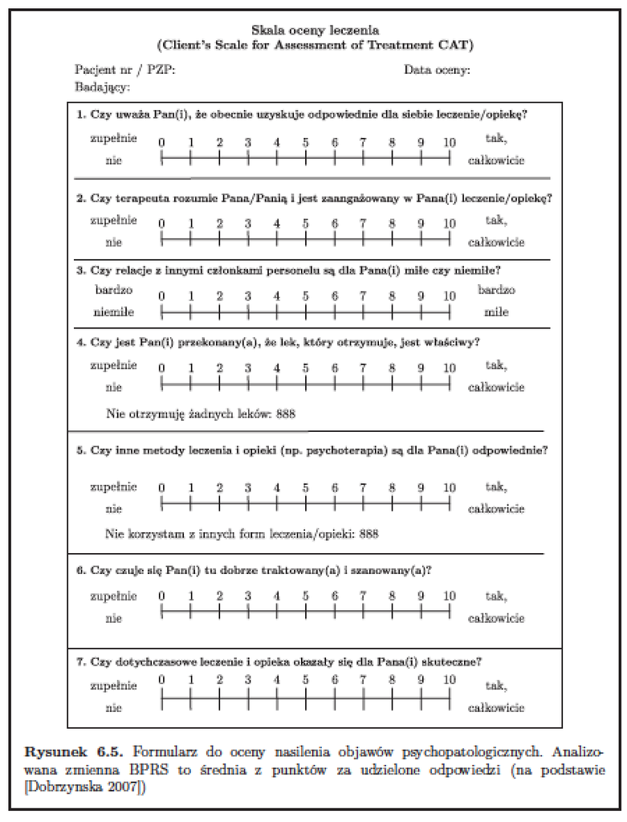

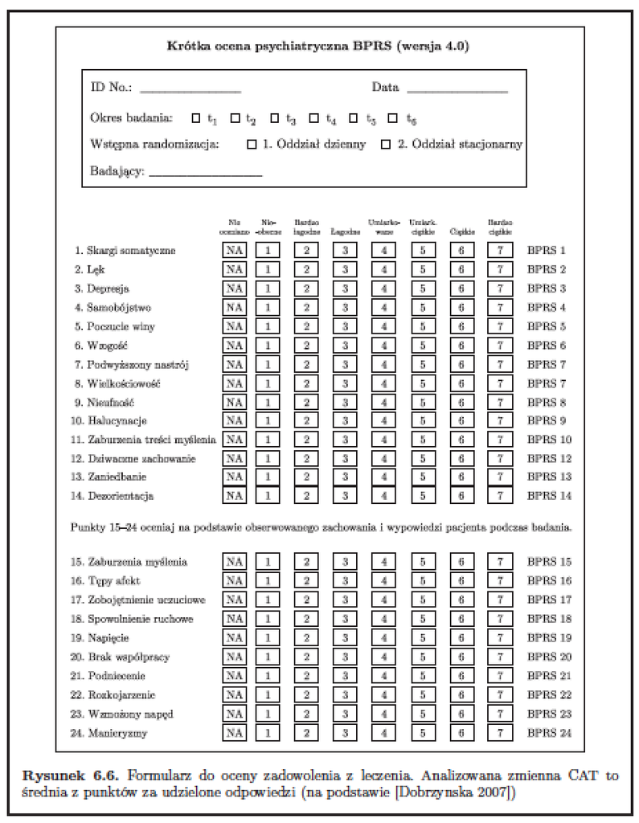

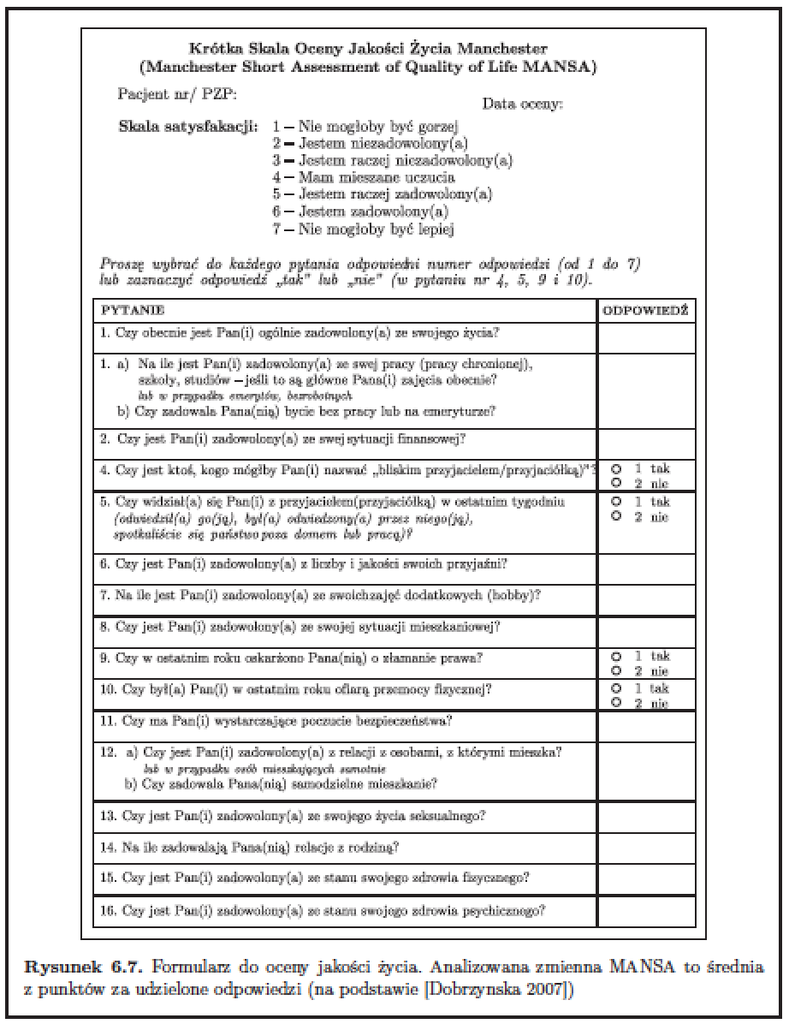

Z jakimi danymi będziemy pracowali

```r
library(PBImisc)
summary(eunomia[,c(1:5,9:11,15)])
```

```
##        CENTRE13      SUBJECT             GENDER          AGE
##  Michalovce:235   Min.   :   1.0   female   : 841   Min.   :18.00
##  London    :226   1st Qu.: 502.8   male     :1167   1st Qu.:29.00
##  Prague    :203   Median :1004.5   not known:   0   Median :38.00
##  Dresden   :186   Mean   :1004.5                    Mean   :38.53
##  Wroclaw   :184   3rd Qu.:1506.2                    3rd Qu.:47.00
##  Naples    :182   Max.   :2008.0                    Max.   :64.00
##  (Other)   :792
##     NUM.HOSP         BPRS.T1         BPRS.T2         BPRS.T3
##  Min.   : 0.000   Min.   :1.000   Min.   :1.000   Min.   :1.000
##  1st Qu.: 4.000   1st Qu.:1.750   1st Qu.:1.333   1st Qu.:1.250
##  Median : 5.000   Median :2.125   Median :1.583   Median :1.500
##  Mean   : 5.566   Mean   :2.241   Mean   :1.713   Mean   :1.583
##  3rd Qu.: 7.000   3rd Qu.:2.583   3rd Qu.:1.958   3rd Qu.:1.792
##  Max.   :17.000   Max.   :5.375   Max.   :4.208   Max.   :5.083
##
##      ICD10
##  F20.0  :649
##  F25.0  :113
##  F31.2  : 71
##  F10.2  : 62
##  F23.0  : 59
##  F20.5  : 55
##  (Other):999
```

### Pytanie

Czy jest zależność pomiędzy liczbą hospitalizacji a liczbą/natężeniem objawów?

Zacznijmy od prostego modelu

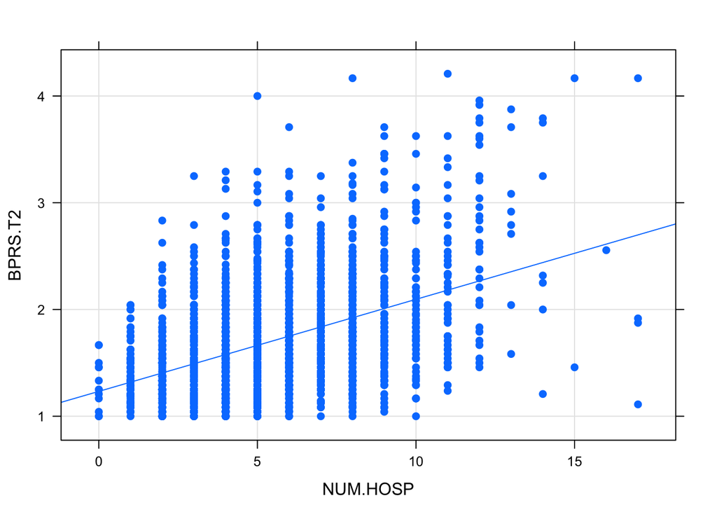

```r
library(lattice)
xyplot(BPRS.T2 ~ NUM.HOSP, eunomia, type = c("g","p","r"), pch=19)
```

Klasyczne efekty stałe

```r
summary(lm(BPRS.T2 ~ NUM.HOSP, eunomia))
```

```
##
## Call:
## lm(formula = BPRS.T2 ~ NUM.HOSP, data = eunomia)
##
## Residuals:
##      Min       1Q   Median       3Q      Max
## -1.58849 -0.32808 -0.08102  0.24937  2.33565
##
## Coefficients:
##             Estimate Std. Error t value Pr(>|t|)
## (Intercept) 1.233001   0.024331   50.68   <2e-16 ***
## NUM.HOSP    0.086271   0.003934   21.93   <2e-16 ***
## ---
## Signif. codes:  0 '***' 0.001 '**' 0.01 '*' 0.05 '.' 0.1 ' ' 1
##
## Residual standard error: 0.4752 on 2006 degrees of freedom
## Multiple R-squared:  0.1934, Adjusted R-squared:  0.193
## F-statistic: 480.9 on 1 and 2006 DF,  p-value: < 2.2e-16
```

```r
summary(lm(BPRS.T2 ~ NUM.HOSP+AGE+GENDER, eunomia))
```

```
##
## Call:
## lm(formula = BPRS.T2 ~ NUM.HOSP + AGE + GENDER, data = eunomia)
##
## Residuals:
##     Min      1Q  Median      3Q     Max
## -1.5796 -0.3288 -0.0829  0.2497  2.2998
##
## Coefficients:
##               Estimate Std. Error t value Pr(>|t|)
## (Intercept)  1.3091339  0.0480099  27.268   <2e-16 ***
## NUM.HOSP     0.0860532  0.0039344  21.872   <2e-16 ***
## AGE         -0.0015689  0.0009478  -1.655    0.098 .
## GENDERmale  -0.0248890  0.0218329  -1.140    0.254
## ---
## Signif. codes:  0 '***' 0.001 '**' 0.01 '*' 0.05 '.' 0.1 ' ' 1
##
## Residual standard error: 0.475 on 2004 degrees of freedom
## Multiple R-squared:  0.1948, Adjusted R-squared:  0.1936
## F-statistic: 161.6 on 3 and 2004 DF,  p-value: < 2.2e-16
```

### Więcej zmiennych

Warto by uwzględnić jeszcze dwa czynniki, ośrodek i diagnozę

Ale jak?

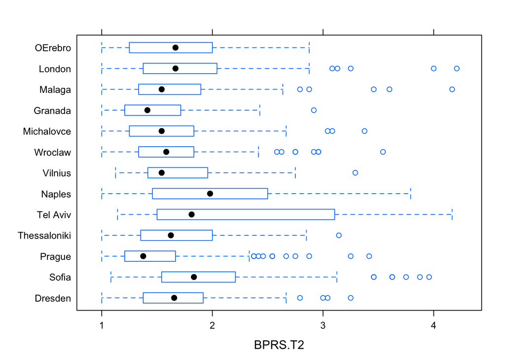

```r
bwplot(CENTRE13~BPRS.T2, data=eunomia)
```

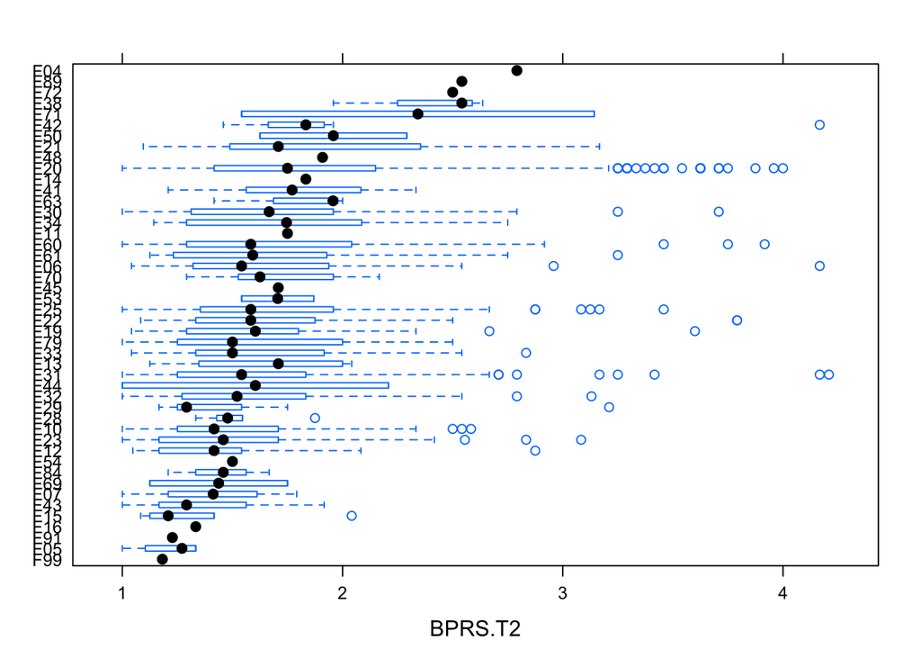

```r
eunomia$ICD103 <- factor(substr(eunomia$ICD10,1,3))
eunomia$ICD103 <- reorder(eunomia$ICD103, eunomia$BPRS.T2, mean)
bwplot(ICD103~BPRS.T2, data=eunomia)
```

Jak zależność pomiędzy NUM.HOSP i BPRS wygląda w różnych ośrodkach?

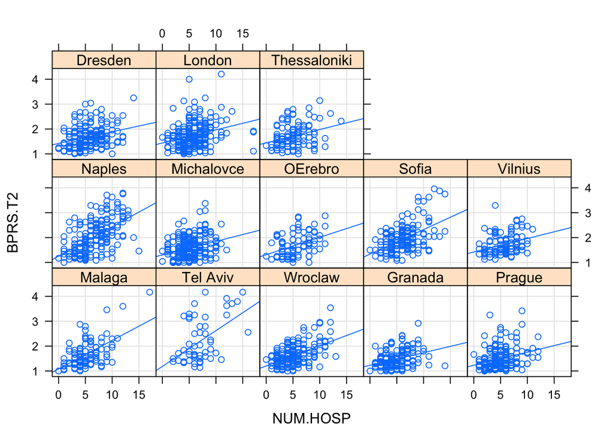

```r
xyplot(BPRS.T2 ~ NUM.HOSP | CENTRE13, eunomia, type = c("g","p","r"), index = function(x,y) coef(lm(y ~ x))[1])
```

### Modelowanie

```r
library(lme4)
lmer(BPRS.T2~NUM.HOSP + (1|CENTRE13) + (1|ICD10), data=eunomia)
```

```
## Linear mixed model fit by REML ['lmerMod']
## Formula: BPRS.T2 ~ NUM.HOSP + (1 | CENTRE13) + (1 | ICD10)
##    Data: eunomia
## REML criterion at convergence: 2572.245
## Random effects:
##  Groups   Name        Std.Dev.
##  ICD10    (Intercept) 0.07496
##  CENTRE13 (Intercept) 0.14814
##  Residual             0.45036
## Number of obs: 2008, groups:  ICD10, 138; CENTRE13, 13
## Fixed Effects:
## (Intercept)     NUM.HOSP
##     1.29469      0.07422
```

```r
# Wald test
# H_0: mu = 0
# (Intercep) = 26.37
2*pnorm(26.37, lower.tail=FALSE)
```

```
## [1] 3.027139e-153
```

```r
# H_0: beta_NUM.HOSP = 0
# (NUM.HOSP) = 19.29
2*pnorm(19.29, lower.tail=FALSE)
```

```
## [1] 6.517331e-83
```

### ML test

Porównajmy model z i bez określonej cechy.

```r
modelFull = lmer(BPRS.T2~NUM.HOSP + (1|CENTRE13) + (1|ICD10), data= eunomia, REML=F)
modelwithoutINT = update(modelFull, . ~ . -1)
modelwithoutNUM = update(modelFull, . ~ . -NUM.HOSP)
```

Funkcje wiarogodności dla tych modeli to

```r
logLik(modelFull)
```

```
## 'log Lik.' -1279.263 (df=5)
```

```r
logLik(modelwithoutINT)
```

```
## 'log Lik.' -1307.415 (df=4)
```

```r
logLik(modelwithoutNUM)
```

```
## 'log Lik.' -1449.809 (df=4)
```

Możemy też policzyć p-wartości dla testu ilorazu funkcji wiarogodności.

```r
anova(modelFull, modelwithoutINT)
```

```
## Data: eunomia
## Models:
## modelwithoutINT: BPRS.T2 ~ NUM.HOSP + (1 | CENTRE13) + (1 | ICD10) - 1
## modelFull: BPRS.T2 ~ NUM.HOSP + (1 | CENTRE13) + (1 | ICD10)
##                 Df    AIC    BIC  logLik deviance  Chisq Chi Df Pr(>Chisq)
## modelwithoutINT  4 2622.8 2645.2 -1307.4   2614.8
## modelFull        5 2568.5 2596.6 -1279.3   2558.5 56.303      1  6.211e-14
##
## modelwithoutINT
## modelFull       ***
## ---
## Signif. codes:  0 '***' 0.001 '**' 0.01 '*' 0.05 '.' 0.1 ' ' 1
```

```r
anova(modelFull, modelwithoutNUM)
```

```
## Data: eunomia
## Models:
## modelwithoutNUM: BPRS.T2 ~ (1 | CENTRE13) + (1 | ICD10)
## modelFull: BPRS.T2 ~ NUM.HOSP + (1 | CENTRE13) + (1 | ICD10)
##                 Df    AIC    BIC  logLik deviance  Chisq Chi Df Pr(>Chisq)
## modelwithoutNUM  4 2907.6 2930.0 -1449.8   2899.6
## modelFull        5 2568.5 2596.6 -1279.3   2558.5 341.09      1  < 2.2e-16
##
## modelwithoutNUM
## modelFull       ***
## ---
## Signif. codes:  0 '***' 0.001 '**' 0.01 '*' 0.05 '.' 0.1 ' ' 1
```

### Permuacje

Alternatywne podejście

```r
N = 99
logs = replicate(N,
 logLik(lmer(BPRS.T2~sample(NUM.HOSP) + (1|CENTRE13) + (1|ICD10),
data=eunomia, REML=F)))
(sum(logs > logLik(modelFull))+1)/(N+1)
```

```
## [1] 0.01
```

### Testy dla efektów losowych

Jak testować całą losową komponentę?

Z testem LRT można testować dowolną liczbę parametrów.

```r
logLik(model1<-lmer(BPRS.T2~NUM.HOSP + (1|CENTRE13) + (1|ICD10), data= eunomia))
```

```
## 'log Lik.' -1286.123 (df=5)
```

```r
logLik(model2<-update(model1, . ~ . -(1|CENTRE13)))
```

```
## 'log Lik.' -1342.145 (df=4)
```

```r
logLik(model3<-update(model1, . ~ . -(1|ICD10)))
```

```
## 'log Lik.' -1297.509 (df=4)
```

```r
# without both random components
logLik(model4 <- lm(BPRS.T2~NUM.HOSP, data=eunomia))
```

```
## 'log Lik.' -1354.166 (df=3)
```

```r
# with ICD10 and CENTER effects included as a fixed effects
logLik(model5 <- lm(BPRS.T2~NUM.HOSP+ICD10+CENTRE13, data=eunomia))
```

```
## 'log Lik.' -1170.856 (df=152)
```

```r
anova(model1, model2)
```

```
## refitting model(s) with ML (instead of REML)
```

```
## Data: eunomia
## Models:
## model2: BPRS.T2 ~ NUM.HOSP + (1 | ICD10)
## model1: BPRS.T2 ~ NUM.HOSP + (1 | CENTRE13) + (1 | ICD10)
##        Df    AIC    BIC  logLik deviance  Chisq Chi Df Pr(>Chisq)
## model2  4 2676.8 2699.2 -1334.4   2668.8
## model1  5 2568.5 2596.6 -1279.3   2558.5 110.25      1  < 2.2e-16 ***
## ---
## Signif. codes:  0 '***' 0.001 '**' 0.01 '*' 0.05 '.' 0.1 ' ' 1
```

```r
anova(model1, model3)
```

```
## refitting model(s) with ML (instead of REML)
```

```
## Data: eunomia
## Models:
## model3: BPRS.T2 ~ NUM.HOSP + (1 | CENTRE13)
## model1: BPRS.T2 ~ NUM.HOSP + (1 | CENTRE13) + (1 | ICD10)
##        Df    AIC    BIC  logLik deviance Chisq Chi Df Pr(>Chisq)
## model3  4 2589.3 2611.7 -1290.6   2581.3
## model1  5 2568.5 2596.6 -1279.3   2558.5 22.76      1  1.835e-06 ***
## ---
## Signif. codes:  0 '***' 0.001 '**' 0.01 '*' 0.05 '.' 0.1 ' ' 1
```

### Permutacje

A teraz test permutacyjny dla efektów losowych.

Zauważ, że p-wartość nie może być mniejsza niż 0.001.

```r
N = 999
eunomia2 = eunomia
logs = replicate(N, {
 eunomia2$ICD10 = sample(eunomia2$ICD10)
 logLik(lmer(BPRS.T2~NUM.HOSP + (1|CENTRE13) + (1|ICD10), data=eunomia2, REML=F))
 })

(sum(logs > logLik(modelFull))+1)/(N+1)
```

```
## [1] 0.001
```

# Praca domowa

Mówiliśmy o złym zachowaniu oceny parametrów $\theta$ na brzegu przestrzeni parametrów. Czy ten rozkład ma szansę być normalny? Sprawdźmy symulacyjnie.

0. Ustal $\theta$
1. Wylosuj dane, macierz Z i X.
2. Wylosuj $\varepsilon$ i $u$.
3. Oceń $\theta$
4. Powtórz kroki od 2 wiele razy (~10 000) i pokaż jak wygląda rozkład $\hat theta$.
5. Zrób to dla metody ML i REML